# Atlas Territorial de Problemáticas en Colombia y Medición de Riesgo LAFT

- Show All Code
- Hide All Code
- View Source

Metodología de Integración de Fuentes Públicas, Estandarización y Ponderación Objetiva CRITIC

Author

Juan José Echeverry

Published

October 8, 2026

# 1 Introducción y Enfoque Metodológico

El presente documento consolida la metodología de manipulación, análisis espacial, modelado estadístico y construcción del **Atlas Territorial de Problemáticas en Colombia**. Su propósito es ofrecer una medición rigurosa, reproducible y objetiva de la intensidad del riesgo asociado al **Lavado de Activos y la Financiación del Terrorismo (LA/FT)** a nivel municipal y departamental.

**Nota de Interpretación y Alcance**

El índice compuesto resultante se interpreta como una **medida de intensidad relativa y concentración territorial**. No constituye una imputación de causalidad ni un juicio ético o institucional sobre las autoridades de un municipio; sintetiza de forma estructurada las señales empíricas observadas en fuentes públicas oficiales para facilitar la toma de decisiones informada basada en riesgos (*Risk-Based Approach* - RBA).

El diseño metodológico se fundamenta en las mejores prácticas internacionales:

1. **Manual para la Construcción de Indicadores Compuestos (OECD / JRC):** Garantiza transparencia en la selección de variables, imputación, normalización, esquema de ponderación y análisis de robustez.
2. **Lineamientos del GAFI / FATF y GAFILAT:** Enfoque basado en riesgos para la identificación de amenazas y vulnerabilidades geográficas.
3. **Principios del Basel AML Index:** Combinación de pesos objetivos derivados de los datos con validación frente a criterios técnicos.

# 2 Fundamentación Jurídica y Delitos Fuente LA/FT

Con base en el **artículo 323 del Código Penal Colombiano** (modificado por las Leyes 599 de 2000, 1121 de 2007, 1474 de 2011, 1762 de 2015 y 2197 de 2022) y las directrices SARLAFT/SAGRILAFT de la Superintendencia Financiera de Colombia (SFC) y la Superintendencia de Sociedades, se estructuran los siguientes delitos fuente principales:

| Tipo | Categoría | Delito Fuente | Referencia Penal / Nota SARLAFT |
| --- | --- | --- | --- |
| **LA** | Drogas | Tráfico de estupefacientes y delitos conexos | CP art. 376 y ss. / Delito fuente clásico |
| **LA** | Criminalidad organizada | Trata de personas | CP art. 188A |
| **LA** | Criminalidad organizada | Tráfico de migrantes | CP art. 188 |
| **LA** | Criminalidad organizada | Secuestro extorsivo | CP art. 169 |
| **LA** | Criminalidad organizada | Extorsión | CP art. 244 |
| **LA** | Comercio exterior | Contrabando / Defraudación aduanera | CP art. 319 / Estatuto Aduanero |
| **LA** | Corrupción | Peculado por apropiación | CP art. 397 |
| **LA** | Corrupción | Cohecho propio e impropio | CP arts. 405–407 |
| **LA** | Corrupción | Concusión | CP art. 404 |
| **LA** | Corrupción | Celebración indebida de contratos | CP art. 410 |
| **LA** | Económicos | Enriquecimiento ilícito de particulares | CP arts. 327–328 |
| **LA** | Armas | Tráfico y porte de armas y municiones | CP art. 366 |
| **LA** | Ambiental | Minería ilegal y explotación ilícita de minerales | CP art. 338 |
| **LA** | Ambiental | Delitos contra los recursos naturales | CP art. 328 |
| **FT** | Terrorismo | Financiación del terrorismo | CP art. 345 |
| **FT** | Terrorismo | Administración de recursos para terrorismo | CP art. 345 (puede originarse en fondos lícitos) |
| **FT** | GAO / GAOr | Apoyo financiero a grupos armados organizados | Enfoque centrado en la destinación |

# 3 Taxonomía de las 13 Dimensiones Territoriales

Para superar las limitaciones de análisis genéricos, el atlas organiza los fenómenos delictivos y las economías ilícitas en **13 dimensiones territoriales específicas**:

1. **`CONT` - Contrabando y economías ilícitas:** Casos de contrabando, piratería terrestre y procesos penales activos por lavado de activos.
2. **`CORR` - Corrupción pública:** Procesos ante la Fiscalía General de la Nación por delitos contra la administración pública.
3. **`AMBI` - Delitos ambientales:** Infracciones y daños contra el medio ambiente y los recursos naturales.
4. **`EXTC` - Extorsión y secuestro:** Hechos delictivos de secuestro y extorsión reportados oficialmente.
5. **`MIEX` - Minería ilegal:** Maquinaria incautada/destruida para extracción ilícita, minas intervenidas y capturas.
6. **`NARC` - Narcotráfico:** Detección de hectáreas de cultivos de coca, incautaciones de estupefacientes (cocaína, base, marihuana, heroína), insumos químicos, laboratorios destruidos y procesos judiciales.
7. **`TFT` - Terrorismo y eventos asociados:** Masacres, afectación de infraestructura vial, minas antipersonal (MAP), voladura de oleoductos y atentados terroristas.
8. **`TRAT` - Trata y migración irregular:** Casos documentados de trata de personas y tráfico ilegal de migrantes.
9. **`HURTO` - Hurto:** Hurto a personas, residencias, comercio, automotores y entidades financieras.
10. **`HOMICIDIOS` - Homicidios:** Tasa de homicidios por cada 100.000 habitantes.
11. **`VIOLENCIA_SEXUAL` - Violencia sexual:** Delitos contra la libertad, integridad y formación sexuales.
12. **`ARMAS` - Armas:** Incautaciones operativas de armas de fuego y municiones.
13. **`CAPTURAS` - Capturas:** Operatividad policial y detenciones por orden judicial o flagrancia.

# 4 Pipeline Metodológico en Python

A continuación se presenta la ejecución secuencial del pipeline analítico. Cada bloque ejecuta una etapa específica mediante código claro, directo y completamente comentado, respetando la restricción de menos de 50 líneas por chunk.

## 4.1 Configuración Inicial, Librerías y Parámetros Globales

**Explicación intuitiva:** Antes de procesar cualquier dato, se importan las herramientas necesarias (`numpy`, `pandas`, `scipy` y `sklearn`), se desactiva la notación científica para asegurar que los números decimales y conteos sean inmediatamente legibles, y se centralizan todas las rutas de archivos y parámetros del modelo (semillas aleatorias, cuantiles de recorte y configuración de clusters).

```python
import sys
from pathlib import Path
import numpy as np
import pandas as pd
import plotnine as p9
from scipy import stats
from sklearn.cluster import KMeans

# -------------------------------------------------------------
# Configuración de formato numérico y notación científica
# -------------------------------------------------------------
# Se suprimen los exponentes científicos (e.g. 1.25e+02 -> 125.0000)
pd.set_option("display.float_format", lambda x: f"{x:.4f}")
pd.set_option("display.max_columns", 25)
pd.set_option("display.width", 1000)
np.set_printoptions(suppress=True, precision=4)

# -------------------------------------------------------------
# Definición de rutas relativas de insumos y salidas
# -------------------------------------------------------------
# Ubicación del archivo de datos dentro de la carpeta del cuaderno
ruta_datos_insumo = Path("data") / "atlas_territorial_publico.xlsx"
if not ruta_datos_insumo.exists():
    ruta_datos_insumo = Path("notebook_methodology") / "data" / "atlas_territorial_publico.xlsx"

# Carpeta central de salida en la raíz donde la app Shiny lee la data
carpeta_data_base = Path("..") / "Data" if (Path("..") / "Data").is_dir() else Path("..") / "data"
if not carpeta_data_base.exists():
    carpeta_data_base = Path("Data") if Path("Data").is_dir() else Path("data")
ruta_salida_parquet = carpeta_data_base / "processed"
ruta_salida_parquet.mkdir(parents=True, exist_ok=True)

# -------------------------------------------------------------
# Parámetros metodológicos globales y paleta de colores
# -------------------------------------------------------------
semilla_aleatoria = 123             # Semilla para garantizar reproducibilidad exacta
cuantiles_winsor = (0.01, 0.99)     # Percentiles 1% y 99% para recorte de outliers
numero_clusters = 4                 # 4 categorías de intensidad de riesgo
nombres_niveles = ["Bajo", "Medio", "Alto", "Muy alto"] # Etiquetas ordenadas
paleta_intensidad = {"Bajo": "#8BC34A", "Medio": "#F2C94C", "Alto": "#F2994A", "Muy alto": "#D7191C"}
iteraciones_kmeans = 100            # Iteraciones máximas por ajuste de cluster
inicializaciones_kmeans = 50        # Múltiples inicios aleatorios para convergencia

print("Parámetros y entorno configurados exitosamente.")
```

```
Parámetros y entorno configurados exitosamente.
```

## 4.2 Definición de Dimensiones y Columnas Clave

**Explicación intuitiva:** Se declaran los identificadores de las 13 dimensiones temáticas que componen el índice y las columnas de metadatos requeridas para la identificación geográfica de los municipios de Colombia.

```python
# Lista canónica de las 13 dimensiones territoriales
lista_dimensiones = [
    "CONT", "CORR", "AMBI", "EXTC", "MIEX", "NARC", "TFT",
    "TRAT", "HURTO", "HOMICIDIOS", "VIOLENCIA_SEXUAL", "ARMAS", "CAPTURAS"
]

# Nombres de las columnas que contendrán la intensidad normalizada por dimensión
columnas_intensidad = [f"{dim}_INTENSIDAD" for dim in lista_dimensiones]

# Nombres de las columnas que contendrán el score ponderado final
columnas_score = [f"{dim}_SCORE" for dim in lista_dimensiones]

# Columnas de identificación geográfica y demográfica municipal
columnas_metadatos = [
    "cod_dpto", "dpto", "cod_mpio", "nom_mpio",
    "tipo_municipio", "longitud", "latitud", "poblacion_total"
]

print(f"Total dimensiones configuradas: {len(lista_dimensiones)}")
print("Lista:", ", ".join(lista_dimensiones))
```

```
Total dimensiones configuradas: 13
Lista: CONT, CORR, AMBI, EXTC, MIEX, NARC, TFT, TRAT, HURTO, HOMICIDIOS, VIOLENCIA_SEXUAL, ARMAS, CAPTURAS
```

## 4.3 Carga y Jerarquización del Catálogo de Indicadores

**Explicación intuitiva:** Se lee el catálogo oficial que describe cada indicador, su fuente administrativa original y si se encuentra activo para la agregación del índice compuesto. Se asegura el tipo de dato de cada campo y su ordenamiento lógico.

```python
# Cargar hoja de catálogo desde el archivo de insumos
df_catalogo = pd.read_excel(ruta_datos_insumo, sheet_name="CATALOGO_INDICADORES")

# Convertir tipos de datos explícitamente para evitar ambigüedades
df_catalogo["dimension_id"] = df_catalogo["dimension_id"].astype(str)
df_catalogo["source_id"] = df_catalogo["source_id"].astype(str)
df_catalogo["included_in_index"] = df_catalogo["included_in_index"].astype(bool)
df_catalogo["dimension_order"] = df_catalogo["dimension_order"].astype(int)
df_catalogo["source_order"] = df_catalogo["source_order"].astype(int)

# Ordenar por el número de orden de dimensión y de fuente
df_catalogo = df_catalogo.sort_values(
    by=["dimension_order", "source_order"]
).reset_index(drop=True)

# Vista previa de las primeras fuentes catalogadas
df_catalogo[["dimension_id", "dimension_label", "source_id", "source_label", "included_in_index"]].head(6)
```

|  | dimension_id | dimension_label | source_id | source_label | included_in_index |
| --- | --- | --- | --- | --- | --- |
| 0 | CONT | Contrabando y economías ilícitas | CONT_CONTR | Contrabando | True |
| 1 | CONT | Contrabando y economías ilícitas | CONT_PIRA | Piratería terrestre | True |
| 2 | CONT | Contrabando y economías ilícitas | CONT_LAVA | Procesos por lavado de activos | True |
| 3 | CORR | Corrupción pública | CORR_PROC | Procesos por corrupción pública | True |
| 4 | AMBI | Delitos ambientales | AMBI_DEL | Delitos ambientales | True |
| 5 | EXTC | Extorsión y secuestro | EXTC_EXT | Extorsión | True |

## 4.4 Carga y Estandarización de Indicadores Municipales

**Explicación intuitiva:** Se leen los registros de cada indicador por municipio. Se formatean los códigos Divipola de departamento (2 dígitos) y municipio (5 dígitos) con ceros a la izquierda y se sanean los valores nulos numéricos.

```python
# Carga de la hoja con las mediciones municipales detalladas
df_indicadores = pd.read_excel(ruta_datos_insumo, sheet_name="INDICADORES_MUNICIPALES")

# Estandarizar códigos Divipola (departamento a 2 dígitos y municipio a 5 dígitos)
df_indicadores["cod_dpto"] = df_indicadores["cod_dpto"].astype(str).str.split(".").str[0].str.zfill(2)
df_indicadores["cod_mpio"] = df_indicadores["cod_mpio"].astype(str).str.split(".").str[0].str.zfill(5)

# Convertir métricas a números de punto flotante reemplazando nulos por ceros
df_indicadores["total"] = pd.to_numeric(df_indicadores["total"], errors="coerce").fillna(0.0)
df_indicadores["tasa"] = pd.to_numeric(df_indicadores["tasa"], errors="coerce").fillna(0.0)
df_indicadores["z_score"] = pd.to_numeric(df_indicadores["z_score"], errors="coerce").fillna(0.0)

print(f"Total registros cargados: {len(df_indicadores):,}")
print(f"Municipios únicos identificados: {df_indicadores['cod_mpio'].nunique():,}")
```

```
Total registros cargados: 39,272
Municipios únicos identificados: 1,122
```

## 4.5 Tratamiento de Outliers (Winsorización) y Escalamiento de Fuentes

**Explicación intuitiva:** En indicadores delictivos suelen existir valores extremos atípicos (e.g. grandes incautaciones en puertos) que sesgan la distribución. Mediante winsorización al percentil 1% y 99% se recortan estos picos atípicos sin descartar la observación, y luego se escala cada variable al rango $[0, 100]$.

```python
# Lista para almacenar los resultados procesados por cada indicador fuente
bloques_fuentes = []

# Procesamiento procedimental agrupando directamente por identificador de fuente
for fuente_id, grupo in df_indicadores.groupby("source_id", sort=False):
    grupo_temp = grupo.copy()
    z_vector = grupo_temp["z_score"].to_numpy(dtype=float)

    # Calcular percentiles 1% y 99% para el recorte de atípicos
    limite_inf = np.nanquantile(z_vector, cuantiles_winsor[0])
    limite_sup = np.nanquantile(z_vector, cuantiles_winsor[1])

    # Recorte (winsorización) directo mediante np.clip
    z_recortado = np.clip(z_vector, limite_inf, limite_sup)
    grupo_temp["z_score_winsor"] = z_recortado

    # Escalamiento Min-Max al rango 0 a 1 y conversión a escala 0 a 100
    rango_z = z_recortado.max() - z_recortado.min()
    norm_01 = (z_recortado - z_recortado.min()) / rango_z if rango_z > 0 else np.zeros_like(z_recortado)
    grupo_temp["source_score_norm"] = norm_01
    grupo_temp["source_score"] = norm_01 * 100.0

    bloques_fuentes.append(grupo_temp)

# Concatenar todos los bloques en el DataFrame final de indicadores
df_indicadores_proc = pd.concat(bloques_fuentes, ignore_index=True)
df_indicadores_proc[["source_id", "cod_mpio", "total", "tasa", "z_score_winsor", "source_score"]].head(5)
```

|  | source_id | cod_mpio | total | tasa | z_score_winsor | source_score |
| --- | --- | --- | --- | --- | --- | --- |
| 0 | CONT_CONTR | 05001 | 32.0000 | 0.1349 | -0.0928 | 2.1132 |
| 1 | CONT_CONTR | 05002 | 0.0000 | 0.0000 | -0.1823 | 0.0000 |
| 2 | CONT_CONTR | 05004 | 0.0000 | 0.0000 | -0.1823 | 0.0000 |
| 3 | CONT_CONTR | 05021 | 0.0000 | 0.0000 | -0.1823 | 0.0000 |
| 4 | CONT_CONTR | 05030 | 0.0000 | 0.0000 | -0.1823 | 0.0000 |

## 4.6 Agregación de Fuentes por Dimensión e Intensidad Municipal

**Explicación intuitiva:** Las fuentes activas se promedian por municipio y dimensión territorial. La intensidad agregada resultante se winsoriza y normaliza entre 0 y 1 para construir la base de comparación homogénea entre dimensiones.

```python
# Filtrar únicamente las fuentes que hacen parte oficial del índice compuesto
fuentes_activas = df_indicadores_proc[df_indicadores_proc["included_in_index"]].copy()

# Promedio simple de los z-scores de las fuentes por municipio y dimensión
df_dims = fuentes_activas.groupby(
    ["cod_mpio", "dimension_id"], as_index=False
)["z_score"].mean().rename(columns={"z_score": "dimension_intensidad_raw"})

# Winsorizar y normalizar procedimentalmente cada una de las 13 dimensiones
bloques_dimensiones = []
for dim_id, grp_dim in df_dims.groupby("dimension_id", sort=False):
    dim_copia = grp_dim.copy()
    valores_raw = dim_copia["dimension_intensidad_raw"].to_numpy(dtype=float)

    q_bajo = np.nanquantile(valores_raw, cuantiles_winsor[0])
    q_alto = np.nanquantile(valores_raw, cuantiles_winsor[1])
    valores_win = np.clip(valores_raw, q_bajo, q_alto)

    dim_copia["dimension_intensidad"] = valores_win
    rango_dim = valores_win.max() - valores_win.min()
    dim_copia["dimension_norm"] = (valores_win - valores_win.min()) / rango_dim if rango_dim > 0 else 0.0
    bloques_dimensiones.append(dim_copia)

df_dimensiones_proc = pd.concat(bloques_dimensiones, ignore_index=True)
df_dimensiones_proc.head(6)
```

|  | cod_mpio | dimension_id | dimension_intensidad_raw | dimension_intensidad | dimension_norm |
| --- | --- | --- | --- | --- | --- |
| 0 | 05001 | AMBI | -0.3572 | -0.3572 | 0.0102 |
| 1 | 05002 | AMBI | -0.2008 | -0.2008 | 0.0675 |
| 2 | 05004 | AMBI | 0.5797 | 0.5797 | 0.3537 |
| 3 | 05021 | AMBI | 0.8809 | 0.8809 | 0.4642 |
| 4 | 05030 | AMBI | -0.1434 | -0.1434 | 0.0886 |
| 5 | 05031 | AMBI | 0.3002 | 0.3002 | 0.2512 |

## 4.7 Construcción de la Matriz de Decisión Territorial

**Explicación intuitiva:** Se transforman las dimensiones de formato largo a formato ancho (una fila por municipio y una columna por dimensión), conformando la matriz de $1.122 \times 13$ requerida para el cálculo de correlaciones y ponderación objetiva.

```python
# Pivotar intensidades por dimensión (formato ancho con municipios en filas)
matriz_intensidad = df_dimensiones_proc.pivot(
    index="cod_mpio", columns="dimension_id", values="dimension_intensidad"
).fillna(0.0)

# Pivotar dimensiones normalizadas (rango 0 a 1)
matriz_normalizada = df_dimensiones_proc.pivot(
    index="cod_mpio", columns="dimension_id", values="dimension_norm"
).fillna(0.0)

# Reorganizar columnas en el orden oficial establecido
matriz_intensidad = matriz_intensidad.reindex(columns=lista_dimensiones)
matriz_normalizada = matriz_normalizada.reindex(columns=lista_dimensiones)

print(f"Dimensiones de la matriz de decisión: {matriz_normalizada.shape} (1122 municipios x 13 dimensiones)")
matriz_normalizada.head(4)
```

```
Dimensiones de la matriz de decisión: (1122, 13) (1122 municipios x 13 dimensiones)
```

| dimension_id cod_mpio | CONT | CORR | AMBI | EXTC | MIEX | NARC | TFT | TRAT | HURTO | HOMICIDIOS | VIOLENCIA_SEXUAL | ARMAS | CAPTURAS |
| --- | --- | --- | --- | --- | --- | --- | --- | --- | --- | --- | --- | --- | --- |
| 05001 | 0.0480 | 0.2451 | 0.0102 | 0.2914 | 0.0009 | 0.0605 | 0.0028 | 0.1021 | 1.0000 | 0.1209 | 0.5905 | 0.1176 | 0.0000 |
| 05002 | 0.0350 | 0.2132 | 0.0675 | 0.1390 | 0.0520 | 0.0637 | 0.1187 | 0.0000 | 0.2364 | 0.2340 | 0.5698 | 0.2984 | 0.0000 |
| 05004 | 0.0000 | 0.0000 | 0.3537 | 0.1259 | 0.2990 | 0.0260 | 0.0291 | 0.0000 | 0.0902 | 0.0308 | 0.2489 | 0.2538 | 0.0000 |
| 05021 | 0.0000 | 0.0000 | 0.4642 | 0.2737 | 0.7080 | 0.0426 | 0.0000 | 0.0000 | 0.2484 | 0.1384 | 0.7553 | 0.3806 | 0.0000 |

## 4.8 Estimación de Pesos Objetivos mediante el Método CRITIC

**Explicación intuitiva:** El método CRITIC (*Criteria Importance Through Intercriteria Correlation*) calcula el peso relativo de cada dimensión a partir de dos propiedades de los datos: 1. **Contraste ($\sigma_j$):** La desviación estándar de cada dimensión normalizada. A mayor dispersión, mayor capacidad de diferenciar municipios. 2. **Conflicto ($\sum [1 - r_{jk}]$):** La suma de correlaciones inversas con las demás dimensiones. Si una dimensión es muy redundante, se penaliza su peso.

La información total se define como:
$$C_j = \sigma_j \sum_{k=1}^m (1 - r_{jk}), \quad w_j = \frac{C_j}{\sum_{k=1}^m C_k}$$

```python
# 1. Contraste: desviación estándar muestral de cada dimensión normalizada
desviaciones_std = matriz_normalizada.std(ddof=1).to_numpy(dtype=float, copy=True)

# 2. Conflicto: cálculo de correlaciones de Pearson entre las 13 dimensiones
matriz_correlaciones = matriz_normalizada.corr(method="pearson").to_numpy(dtype=float, copy=True)
np.nan_to_num(matriz_correlaciones, copy=False, nan=0.0)
np.fill_diagonal(matriz_correlaciones, 1.0) # Diagonal siempre unitaria

# 3. No-redundancia: suma de (1 - r_jk) para cada dimensión
conflictos = np.sum(1.0 - matriz_correlaciones, axis=1)

# 4. Cantidad de información C_j y normalización a suma 1
vector_informacion = desviaciones_std * conflictos
pesos_critic = vector_informacion / np.sum(vector_informacion)

# Diccionario de pesos y tabla explicativa ordenada
dict_pesos = dict(zip(lista_dimensiones, pesos_critic))
df_pesos = pd.DataFrame({
    "dimension_id": lista_dimensiones,
    "peso": pesos_critic,
    "peso_pct": pesos_critic * 100.0,
    "desviacion_std": desviaciones_std,
    "conflicto_info": conflictos
}).sort_values(by="peso", ascending=False).reset_index(drop=True)

df_pesos
```

|  | dimension_id | peso | peso_pct | desviacion_std | conflicto_info |
| --- | --- | --- | --- | --- | --- |
| 0 | HURTO | 0.1020 | 10.1954 | 0.2070 | 10.8711 |
| 1 | VIOLENCIA_SEXUAL | 0.0970 | 9.6982 | 0.2031 | 10.5410 |
| 2 | ARMAS | 0.0921 | 9.2146 | 0.1929 | 10.5444 |
| 3 | CORR | 0.0892 | 8.9229 | 0.1784 | 11.0395 |
| 4 | HOMICIDIOS | 0.0865 | 8.6528 | 0.1995 | 9.5734 |
| 5 | NARC | 0.0822 | 8.2152 | 0.1872 | 9.6890 |
| 6 | AMBI | 0.0802 | 8.0154 | 0.1633 | 10.8324 |
| 7 | EXTC | 0.0775 | 7.7483 | 0.1747 | 9.7892 |
| 8 | CONT | 0.0772 | 7.7231 | 0.1623 | 10.5043 |
| 9 | MIEX | 0.0745 | 7.4534 | 0.1488 | 11.0569 |
| 10 | TRAT | 0.0717 | 7.1687 | 0.1438 | 11.0031 |
| 11 | TFT | 0.0699 | 6.9920 | 0.1488 | 10.3739 |
| 12 | CAPTURAS | 0.0000 | 0.0000 | 0.0000 | 12.0000 |

### 4.8.1 Visualización de Ponderaciones CRITIC con Plotnine

**Explicación intuitiva:** Para interpretar visualmente la importancia relativa asignada a cada problemática, se genera un diagrama de barras horizontal ordenado mediante `plotnine` (gramática de gráficos estilo `ggplot2`). Este gráfico permite identificar qué dimensiones aportan mayor información objetiva al índice general en función de su contraste y su baja correlación con las demás variables.

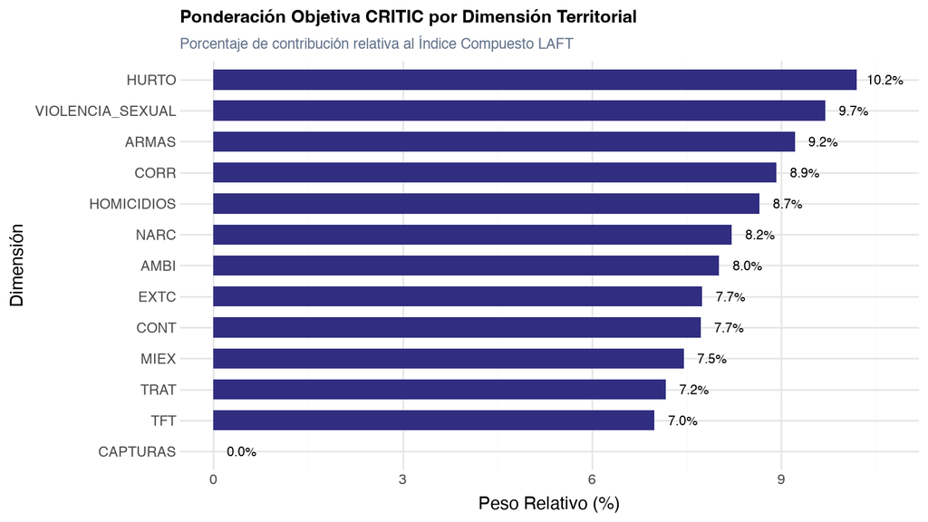

```python
# Preparar datos ordenados para el gráfico de barras horizontal
df_pesos_grafico = df_pesos.copy()
df_pesos_grafico["dimension_id"] = pd.Categorical(
    df_pesos_grafico["dimension_id"],
    categories=df_pesos_grafico.sort_values("peso_pct")["dimension_id"],
    ordered=True
)

# Construir gráfico de barras ordenado con plotnine
grafico_pesos = (
    p9.ggplot(df_pesos_grafico, p9.aes(x="dimension_id", y="peso_pct"))
    + p9.geom_col(fill="#312e81", width=0.65)
    + p9.geom_text(
        p9.aes(label="peso_pct.round(1).astype(str) + '%'"),
        nudge_y=0.45,
        size=8
    )
    + p9.coord_flip()
    + p9.labs(
        title="Ponderación Objetiva CRITIC por Dimensión Territorial",
        subtitle="Porcentaje de contribución relativa al Índice Compuesto LAFT",
        x="Dimensión",
        y="Peso Relativo (%)"
    )
    + p9.theme_minimal()
    + p9.theme(
        figure_size=(8, 4.5),
        plot_title=p9.element_text(weight="bold", size=11),
        plot_subtitle=p9.element_text(color="#64748b", size=9)
    )
)

grafico_pesos
```

## 4.9 Ponderación de Scores y Cálculo del Índice Territorial Compuesto

**Explicación intuitiva:** Cada dimensión normalizada se multiplica por su peso objetivo oficial y se escala a 100 puntos. La suma de estos scores conforma el **Índice Territorial Compuesto** ($[0, 100]$), el cual posteriormente se estandariza ($z$-score).

```python
# Calcular scores por dimensión multiplicando por el peso CRITIC y factor 100
matriz_scores = matriz_normalizada.copy()
for dim in lista_dimensiones:
    matriz_scores[dim] = matriz_scores[dim] * dict_pesos[dim] * 100.0

# Renombrar columnas para identificación unívoca
matriz_scores.columns = [f"{dim}_SCORE" for dim in lista_dimensiones]
matriz_intensidad.columns = [f"{dim}_INTENSIDAD" for dim in lista_dimensiones]

# Calcular el Índice Territorial Compuesto sumando las 13 dimensiones
indice_territorial = matriz_scores.sum(axis=1).to_numpy(dtype=float)

# Estandarización z-score del índice municipal
media_global = np.mean(indice_territorial)
desv_global = np.std(indice_territorial, ddof=1)
indice_z = (indice_territorial - media_global) / desv_global

# Ensamble de la tabla de cálculos por municipio
df_calculo_mun = pd.DataFrame({
    "cod_mpio": matriz_normalizada.index,
    "INDICE_TERRITORIAL": indice_territorial,
    "INDICE_TERRITORIAL_Z": indice_z
}).merge(matriz_intensidad, on="cod_mpio").merge(matriz_scores, on="cod_mpio")

df_calculo_mun[["cod_mpio", "INDICE_TERRITORIAL", "INDICE_TERRITORIAL_Z"]].head(5)
```

|  | cod_mpio | INDICE_TERRITORIAL | INDICE_TERRITORIAL_Z |
| --- | --- | --- | --- |
| 0 | 05001 | 24.2045 | 0.8955 |
| 1 | 05002 | 18.2430 | 0.1776 |
| 2 | 05004 | 12.3943 | -0.5267 |
| 3 | 05021 | 26.0316 | 1.1155 |
| 4 | 05030 | 20.0282 | 0.3926 |

## 4.10 Clasificación Jerárquica Municipal mediante K-Means ($k=4$)

**Explicación intuitiva:** Para convertir los puntajes continuos en categorías operativas para analistas y oficiales de cumplimiento, se ejecuta el algoritmo K-Means con $k=4$ sobre el $z$-score del índice, asignando las etiquetas: “Bajo”, “Medio”, “Alto” y “Muy alto” en estricto orden de sus centroides.

```python
# Configuración y ajuste de K-Means sobre el z-score del índice territorial
modelo_kmeans = KMeans(
    n_clusters=numero_clusters,
    n_init=inicializaciones_kmeans,
    max_iter=iteraciones_kmeans,
    random_state=semilla_aleatoria
)

# Ajuste unidimensional del modelo
vector_z = df_calculo_mun["INDICE_TERRITORIAL_Z"].to_numpy(dtype=float).reshape(-1, 1)
prediccion_cluster = modelo_kmeans.fit_predict(vector_z)

# Ordenamiento de centroides para garantizar progresión monótona
centroides_obtenidos = modelo_kmeans.cluster_centers_.flatten()
orden_centroides = np.argsort(centroides_obtenidos)
mapa_niveles = {orden_centroides[i]: nombres_niveles[i] for i in range(numero_clusters)}
mapa_cluster_ids = {orden_centroides[i]: i + 1 for i in range(numero_clusters)}

# Asignar niveles y centroides ordenados
df_calculo_mun["cluster_total"] = [mapa_cluster_ids[c] for c in prediccion_cluster]
df_calculo_mun["intensidad_territorial"] = [mapa_niveles[c] for c in prediccion_cluster]
df_calculo_mun["intensidad"] = df_calculo_mun["cluster_total"].map(
    dict(zip(range(1, numero_clusters + 1), centroides_obtenidos[orden_centroides]))
)

# Resumen de distribución municipal resultante
conteo_distribucion = df_calculo_mun["intensidad_territorial"].value_counts().reindex(nombres_niveles)
pd.DataFrame({"Nivel": conteo_distribucion.index, "Municipios": conteo_distribucion.values})
```

|  | Nivel | Municipios |
| --- | --- | --- |
| 0 | Bajo | 390 |
| 1 | Medio | 413 |
| 2 | Alto | 230 |
| 3 | Muy alto | 89 |

### 4.10.1 Visualización de la Distribución Municipal con Plotnine

**Explicación intuitiva:** Para verificar el comportamiento de la segmentación K-Means sobre el continuo territorial, se genera un histograma con la distribución del Índice Compuesto coloreado según los 4 niveles de riesgo. Este gráfico ilustra cómo se agrupan los municipios y los cortes empíricos generados por el algoritmo.

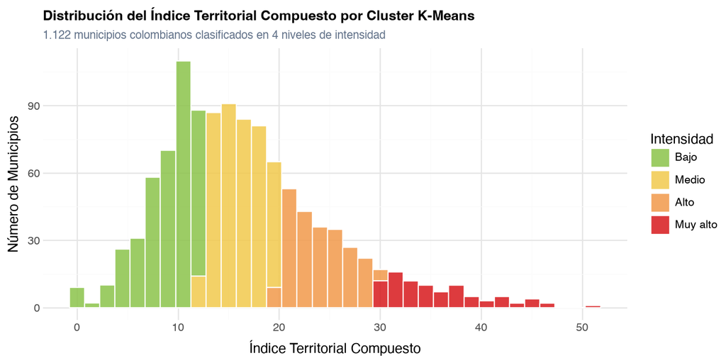

```python
# Preparar datos categóricos ordenados para plotnine
df_plot_mun = df_calculo_mun.copy()
df_plot_mun["intensidad_territorial"] = pd.Categorical(
    df_plot_mun["intensidad_territorial"],
    categories=nombres_niveles,
    ordered=True
)

# Histograma del índice compuesto por categoría de riesgo
grafico_distribucion_mun = (
    p9.ggplot(df_plot_mun, p9.aes(x="INDICE_TERRITORIAL", fill="intensidad_territorial"))
    + p9.geom_histogram(bins=35, color="white", alpha=0.85)
    + p9.scale_fill_manual(values=paleta_intensidad)
    + p9.labs(
        title="Distribución del Índice Territorial Compuesto por Cluster K-Means",
        subtitle="1.122 municipios colombianos clasificados en 4 niveles de intensidad",
        x="Índice Territorial Compuesto",
        y="Número de Municipios",
        fill="Intensidad"
    )
    + p9.theme_minimal()
    + p9.theme(
        figure_size=(8, 4),
        plot_title=p9.element_text(weight="bold", size=11),
        plot_subtitle=p9.element_text(color="#64748b", size=9)
    )
)

grafico_distribucion_mun
```

### 4.10.2 Frecuencia Territorial por Nivel de Riesgo

**Explicación intuitiva:** Este gráfico de barras sintetiza el número absoluto y la participación porcentual de los municipios del país en cada una de las 4 categorías, evidenciando que la gran mayoría del territorio nacional se concentra en niveles bajos o medios, mientras que los municipios de intensidad alta y muy alta representan focos específicos y prioritarios de atención.

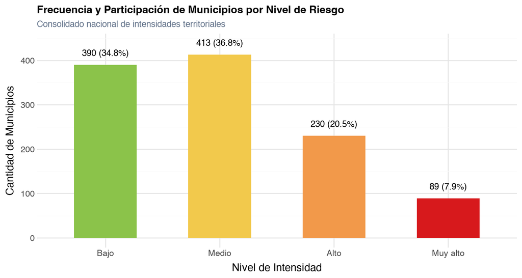

```python
# Tabla resumen de frecuencias para el gráfico de barras
df_frec_mun = (
    df_plot_mun["intensidad_territorial"]
    .value_counts()
    .reindex(nombres_niveles)
    .reset_index()
)
df_frec_mun.columns = ["nivel", "conteo"]
df_frec_mun["porcentaje"] = (df_frec_mun["conteo"] / len(df_plot_mun)) * 100.0
df_frec_mun["nivel"] = pd.Categorical(df_frec_mun["nivel"], categories=nombres_niveles, ordered=True)

# Construcción del gráfico de barras con plotnine
grafico_barras_niveles = (
    p9.ggplot(df_frec_mun, p9.aes(x="nivel", y="conteo", fill="nivel"))
    + p9.geom_col(show_legend=False, width=0.55)
    + p9.geom_text(
        p9.aes(label="conteo.astype(str) + ' (' + porcentaje.round(1).astype(str) + '%)'"),
        nudge_y=25,
        size=9
    )
    + p9.scale_fill_manual(values=paleta_intensidad)
    + p9.labs(
        title="Frecuencia y Participación de Municipios por Nivel de Riesgo",
        subtitle="Consolidado nacional de intensidades territoriales",
        x="Nivel de Intensidad",
        y="Cantidad de Municipios"
    )
    + p9.theme_minimal()
    + p9.theme(
        figure_size=(7.5, 4),
        plot_title=p9.element_text(weight="bold", size=11),
        plot_subtitle=p9.element_text(color="#64748b", size=9)
    )
)

grafico_barras_niveles
```

## 4.11 Ensamble Final de Municipios con Metadatos Oficiales

**Explicación intuitiva:** Se vinculan los cálculos y clasificaciones con la información demográfica censal oficial del DANE (nombres, departamentos, coordenadas y población total), conformando la base `municipios_total`.

```python
# Cargar metadatos oficiales del DANE desde la hoja de insumo
df_base_original = pd.read_excel(ruta_datos_insumo, sheet_name="TOTAL_TERRITORIAL")
df_base_original["cod_dpto"] = df_base_original["cod_dpto"].astype(str).str.split(".").str[0].str.zfill(2)
df_base_original["cod_mpio"] = df_base_original["cod_mpio"].astype(str).str.split(".").str[0].str.zfill(5)

# Extraer únicamente columnas de metadatos geográficos y demográficos
df_geometadatos = df_base_original[columnas_metadatos].drop_duplicates(subset=["cod_mpio"]).copy()

# Unión izquierda con los cálculos del modelo
df_municipios_final = df_geometadatos.merge(df_calculo_mun, on="cod_mpio", how="left")
df_municipios_final["METODO_INDICE"] = "CRITIC sobre dimensiones territoriales con fuentes winsorizadas 1%-99%"

print(f"Total municipios consolidados: {len(df_municipios_final):,}")
df_municipios_final[["cod_mpio", "nom_mpio", "dpto", "INDICE_TERRITORIAL", "intensidad_territorial"]].head(5)
```

```
Total municipios consolidados: 1,122
```

|  | cod_mpio | nom_mpio | dpto | INDICE_TERRITORIAL | intensidad_territorial |
| --- | --- | --- | --- | --- | --- |
| 0 | 05001 | MEDELLÍN | ANTIOQUIA | 24.2045 | Alto |
| 1 | 05002 | ABEJORRAL | ANTIOQUIA | 18.2430 | Medio |
| 2 | 05004 | ABRIAQUÍ | ANTIOQUIA | 12.3943 | Bajo |
| 3 | 05021 | ALEJANDRÍA | ANTIOQUIA | 26.0316 | Alto |
| 4 | 05030 | AMAGÁ | ANTIOQUIA | 20.0282 | Medio |

## 4.12 Agregación Departamental Ponderada por Población

**Explicación intuitiva:** Para obtener el índice de los 32 departamentos y Bogotá D.C., no se calcula un promedio simple de municipios (lo cual sobrerrepresentaría municipios pequeños despoblados), sino un **promedio ponderado por la población censal** de cada municipio:
$$\text{Índice}_{\text{depto}} = \frac{\sum_{i \in \text{Depto}} \text{Índice}_i \times \text{Población}_i}{\sum_{i \in \text{Depto}} \text{Población}_i}$$

```python
# Lista para recolectar las estadísticas agregadas departamentales
registros_departamentos = []

# Iteración por departamento para calcular promedios ponderados y conteos
for (cod_dpto, nom_dpto), subgrupo in df_municipios_final.groupby(["cod_dpto", "dpto"], sort=True):
    pob_depto = subgrupo["poblacion_total"].sum()
    total_mpios = len(subgrupo)

    # Cálculo del índice departamental ponderado por población
    if pob_depto > 0:
        idx_depto_ponderado = (subgrupo["INDICE_TERRITORIAL"] * subgrupo["poblacion_total"]).sum() / pob_depto
    else:
        idx_depto_ponderado = subgrupo["INDICE_TERRITORIAL"].mean()

    conteo_niv = subgrupo["intensidad_territorial"].value_counts()

    registros_departamentos.append({
        "cod_dpto": cod_dpto,
        "dpto": nom_dpto,
        "poblacion_total_depto": pob_depto,
        "municipios_total": total_mpios,
        "municipios_bajo": conteo_niv.get("Bajo", 0),
        "municipios_medio": conteo_niv.get("Medio", 0),
        "municipios_alto": conteo_niv.get("Alto", 0),
        "municipios_muy_alto": conteo_niv.get("Muy alto", 0),
        "INDICE_TERRITORIAL_DEPTO": idx_depto_ponderado
    })

df_deptos_final = pd.DataFrame(registros_departamentos)
df_deptos_final = df_deptos_final.sort_values(by="INDICE_TERRITORIAL_DEPTO", ascending=False).reset_index(drop=True)
df_deptos_final.head(5)
```

|  | cod_dpto | dpto | poblacion_total_depto | municipios_total | municipios_bajo | municipios_medio | municipios_alto | municipios_muy_alto | INDICE_TERRITORIAL_DEPTO |
| --- | --- | --- | --- | --- | --- | --- | --- | --- | --- |
| 0 | 88 | ARCHIPIÉLAGO DE SAN ANDRÉS, PROVIDENCIA Y SANT... | 48299 | 2 | 0 | 0 | 0 | 2 | 41.6099 |
| 1 | 95 | GUAVIARE | 73081 | 4 | 0 | 0 | 0 | 4 | 39.2309 |
| 2 | 81 | ARAUCA | 239503 | 7 | 0 | 0 | 4 | 3 | 30.7591 |
| 3 | 86 | PUTUMAYO | 283197 | 13 | 0 | 4 | 4 | 5 | 29.1886 |
| 4 | 50 | META | 919129 | 29 | 0 | 10 | 13 | 6 | 26.6509 |

## 4.13 Clasificación Jerárquica Departamental con K-Means

**Explicación intuitiva:** De manera análoga al nivel municipal, se estandariza el índice departamental y se aplica K-Means ($k=4$) para agrupar los departamentos en los 4 niveles de intensidad.

```python
# Estandarización del índice departamental
z_departamental = stats.zscore(df_deptos_final["INDICE_TERRITORIAL_DEPTO"].to_numpy(dtype=float))
df_deptos_final["INDICE_TERRITORIAL_DEPTO_Z"] = z_departamental

# Ajuste de K-Means departamental con parámetros iniciales
km_deptos = KMeans(n_clusters=numero_clusters, n_init=50, max_iter=100, random_state=semilla_aleatoria)
clusters_deptos = km_deptos.fit_predict(z_departamental.reshape(-1, 1))

# Mapeo de niveles ordenados por centroide
centros_dpto = km_deptos.cluster_centers_.flatten()
orden_dpto = np.argsort(centros_dpto)
mapa_niv_dpto = {orden_dpto[i]: nombres_niveles[i] for i in range(numero_clusters)}
mapa_ids_dpto = {orden_dpto[i]: i + 1 for i in range(numero_clusters)}

df_deptos_final["cluster_total_depto"] = [mapa_ids_dpto[c] for c in clusters_deptos]
df_deptos_final["intensidad_territorial_depto"] = [mapa_niv_dpto[c] for c in clusters_deptos]
df_deptos_final["METODO_DEPTO"] = "Promedio ponderado por población municipal clasificado por K-Means"

df_deptos_final[["cod_dpto", "dpto", "municipios_total", "INDICE_TERRITORIAL_DEPTO", "intensidad_territorial_depto"]].head(6)
```

|  | cod_dpto | dpto | municipios_total | INDICE_TERRITORIAL_DEPTO | intensidad_territorial_depto |
| --- | --- | --- | --- | --- | --- |
| 0 | 88 | ARCHIPIÉLAGO DE SAN ANDRÉS, PROVIDENCIA Y SANT... | 2 | 41.6099 | Muy alto |
| 1 | 95 | GUAVIARE | 4 | 39.2309 | Muy alto |
| 2 | 81 | ARAUCA | 7 | 30.7591 | Alto |
| 3 | 86 | PUTUMAYO | 13 | 29.1886 | Alto |
| 4 | 50 | META | 29 | 26.6509 | Alto |
| 5 | 19 | CAUCA | 42 | 25.2899 | Alto |

### 4.13.1 Visualización del Ranking Departamental con Plotnine

**Explicación intuitiva:** Para contrastar el nivel de riesgo agregado entre las principales entidades territoriales del país, se grafica el Top 15 de departamentos con mayor Índice Territorial Ponderado, diferenciando con color el nivel de intensidad resultante del clustering K-Means.

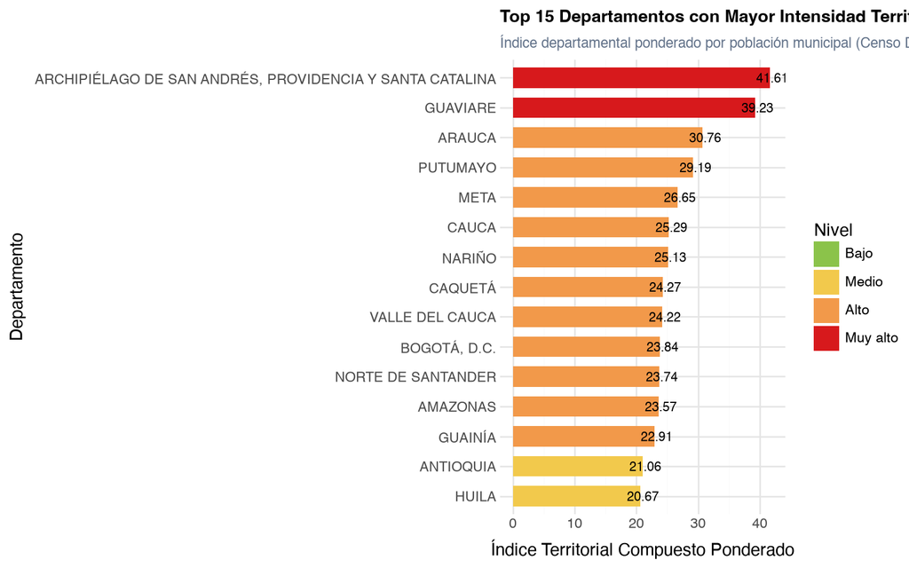

```python
# Seleccionar los 15 departamentos con mayor índice ponderado
df_top_deptos = df_deptos_final.sort_values(by="INDICE_TERRITORIAL_DEPTO", ascending=False).head(15).copy()

# Ordenar categorías para presentación en el eje vertical
df_top_deptos["dpto"] = pd.Categorical(
    df_top_deptos["dpto"],
    categories=df_top_deptos.sort_values("INDICE_TERRITORIAL_DEPTO")["dpto"],
    ordered=True
)
df_top_deptos["intensidad_territorial_depto"] = pd.Categorical(
    df_top_deptos["intensidad_territorial_depto"],
    categories=nombres_niveles,
    ordered=True
)

# Gráfico de barras horizontal con plotnine
grafico_top_deptos = (
    p9.ggplot(df_top_deptos, p9.aes(x="dpto", y="INDICE_TERRITORIAL_DEPTO", fill="intensidad_territorial_depto"))
    + p9.geom_col(width=0.68)
    + p9.geom_text(
        p9.aes(label="INDICE_TERRITORIAL_DEPTO.round(2).astype(str)"),
        nudge_y=0.4,
        size=8
    )
    + p9.scale_fill_manual(values=paleta_intensidad)
    + p9.coord_flip()
    + p9.labs(
        title="Top 15 Departamentos con Mayor Intensidad Territorial Agregada",
        subtitle="Índice departamental ponderado por población municipal (Censo DANE)",
        x="Departamento",
        y="Índice Territorial Compuesto Ponderado",
        fill="Nivel"
    )
    + p9.theme_minimal()
    + p9.theme(
        figure_size=(8, 5),
        plot_title=p9.element_text(weight="bold", size=11),
        plot_subtitle=p9.element_text(color="#64748b", size=9)
    )
)

grafico_top_deptos
```

## 4.14 Exportación Oficial de Archivos Parquet para la Aplicación Shiny

**Explicación intuitiva:** Todos los conjuntos de datos generados y validados por el cuaderno se exportan en formato columnar Parquet comprimido hacia el directorio central `data/processed/` del proyecto. Esto garantiza que la aplicación web interactiva consuma exactamente la data producida por la metodología.

```python
# 1. Catálogo de indicadores y fuentes
df_catalogo.to_parquet(ruta_salida_parquet / "catalogo_indicadores.parquet", index=False)

# 2. Base de datos municipal consolidada con scores y clusters
df_municipios_final.to_parquet(ruta_salida_parquet / "municipios_total.parquet", index=False)

# 3. Base de datos departamental agregada
df_deptos_final.to_parquet(ruta_salida_parquet / "departamentos_total.parquet", index=False)

# 4. Detalle de indicadores por municipio
df_indicadores_proc.to_parquet(ruta_salida_parquet / "indicadores_municipales.parquet", index=False)

# 5. Tabla de ponderadores objetivos CRITIC
df_pesos.to_parquet(ruta_salida_parquet / "pesos_objetivos.parquet", index=False)

# 6. Matriz larga de dimensiones
df_dimensiones_proc.to_parquet(ruta_salida_parquet / "dimensiones_municipales.parquet", index=False)

print(f"Exportación exitosa en formato Parquet a: {ruta_salida_parquet.resolve()}")
```

```
Exportación exitosa en formato Parquet a: /Users/juanjoseecheverry/Library/Mobile Documents/com~apple~CloudDocs/Personal Code Portfolio/Riesgo LAFT/Data/processed
```

## 4.15 Pruebas de Consistencia y Auditoría de Integridad Metodológica

**Explicación intuitiva:** Para verificar que el proceso analítico no presentó pérdidas de información, sesgos o inconsistencias matemáticas, se ejecutan pruebas automatizadas que certifican la integridad del modelo.

```python
# Definición de criterios de control de calidad
pruebas_calidad = {
    "Total municipios es exactamente 1.122": len(df_municipios_final) == 1122,
    "Total departamentos es exactamente 33": len(df_deptos_final) == 33,
    "Suma de pesos CRITIC es 1.0 (±1e-6)": abs(df_pesos["peso"].sum() - 1.0) < 1e-6,
    "Total de dimensiones es exactamente 13": len(df_pesos) == 13,
    "Sin valores nulos en el índice territorial": df_municipios_final["INDICE_TERRITORIAL"].isna().sum() == 0,
    "Todas las puntuaciones son valores finitos": np.isfinite(df_municipios_final["INDICE_TERRITORIAL"]).all(),
}

# Consolidar reporte de auditoría
df_auditoria = pd.DataFrame([
    {"Validación": criterio, "Estado": "PASS" if resultado else "FAIL"}
    for criterio, resultado in pruebas_calidad.items()
])

# Comprobar que todas las validaciones hayan aprobado satisfactoriamente
assert all(pruebas_calidad.values()), "¡Error! Una o más validaciones metodológicas no pasaron."
df_auditoria
```

|  | Validación | Estado |
| --- | --- | --- |
| 0 | Total municipios es exactamente 1.122 | PASS |
| 1 | Total departamentos es exactamente 33 | PASS |
| 2 | Suma de pesos CRITIC es 1.0 (±1e-6) | PASS |
| 3 | Total de dimensiones es exactamente 13 | PASS |
| 4 | Sin valores nulos en el índice territorial | PASS |
| 5 | Todas las puntuaciones son valores finitos | PASS |

# 5 Conclusiones y Trazabilidad

El pipeline metodológico implementado provee: 1. **Transparencia Total:** Toda transformación desde los datos brutos hasta las clasificaciones de riesgo se documenta y ejecuta de forma lineal y auditable. 2. **Robustez Matemática:** La normalización Min-Max tras winsorización neutraliza el impacto distorsionante de valores extremos, mientras que la técnica CRITIC elimina la arbitrariedad en la asignación de ponderadores. 3. **Consumo Directo en la App Shiny:** Las salidas Parquet generadas alimentan inmediatamente el tablero interactivo en la raíz del proyecto (`app.py`), facilitando el análisis visual, geoespacial y comparativo a tomadores de decisiones.